# Chapter 2

Harrison Linder

2024-02-19

### 2.1.2 Setup Lancaster data

```r
options(scipen=999)

library(tidyverse)
library(sf)
library(gridExtra)
library(grid)
library(kableExtra)
root.dir = "https://raw.githubusercontent.com/urbanSpatial/Public-Policy-Analytics-Landing/master/DATA/"
source("https://raw.githubusercontent.com/urbanSpatial/Public-Policy-Analytics-Landing/master/functions.r")
```

`studyAreaTowns` - A polygon layer of town polygons inside of the Lancaster County study area. Note that there is a MUNI or municipal town name for each town polygon. `uga` - A polygon layer of the spatial extent of Lancaster County’s Urban Growth Area. `lancCounty` - A polygon layer of the spatial extent of Lancaster County. `buildings` - A polygon layer of the footprint for all buildings in the study area. `greenSpace` - A polygon layer showing areas classified as non-developed land cover as classified by the USGS.

```r
lancCounty <- st_read(file.path(root.dir,"/Chapter2/LancasterCountyBoundary.geojson")) %>%
  st_transform('ESRI:102728')
uga <- st_read(file.path(root.dir,"/Chapter2/Urban_Growth_Boundary.geojson")) %>%
  st_transform('ESRI:102728')
studyAreaTowns <- st_read(file.path(root.dir,"/Chapter2/StudyAreaTowns.geojson")) %>%
  st_transform('ESRI:102728')
buildings <- st_read(file.path(root.dir,"/Chapter2/LancasterCountyBuildings.geojson")) %>%
  st_transform('ESRI:102728')
greenSpace <- st_read(file.path(root.dir,"/Chapter2/LancasterGreenSpace.geojson")) %>%
  st_transform('ESRI:102728')
```

the textbook uses `st_buffer` to remove some of the ‘extraneous slivers’ within the UGA. I’m going to visualize this to see what it means.

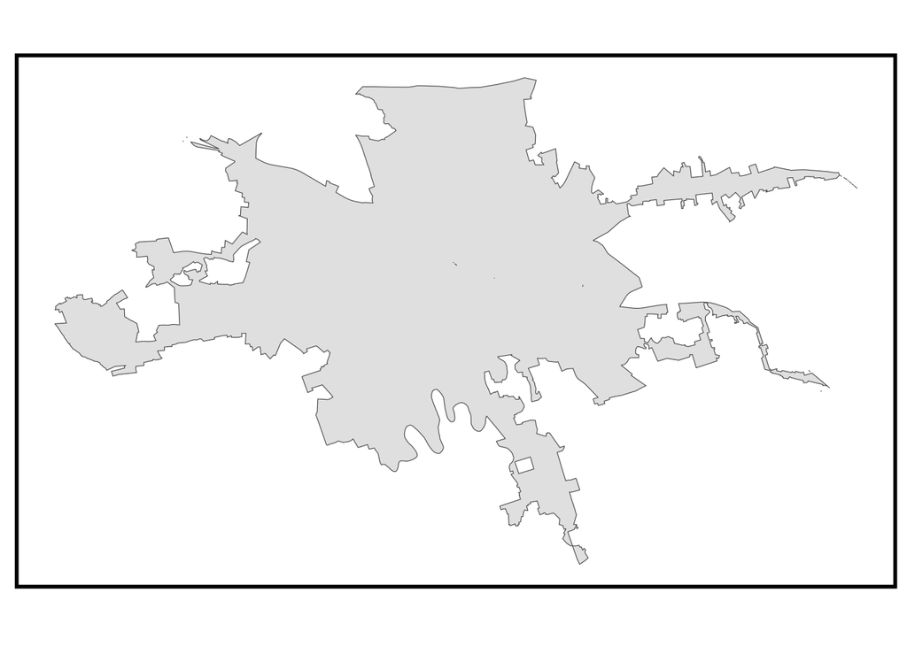

```r
uga_union <-
     st_union(uga) %>%
  st_buffer(dist = 1) %>% #the buffer adds to the existing area of the object. since it's only one object, overlaps seem to be automatically unionized. Our distance unit appears to be feet. The little chunks wer are getting rid of are exceedinly small it seems.
  st_sf()

ggplot() +
    geom_sf(data = st_union(uga)) +
    mapTheme()
```

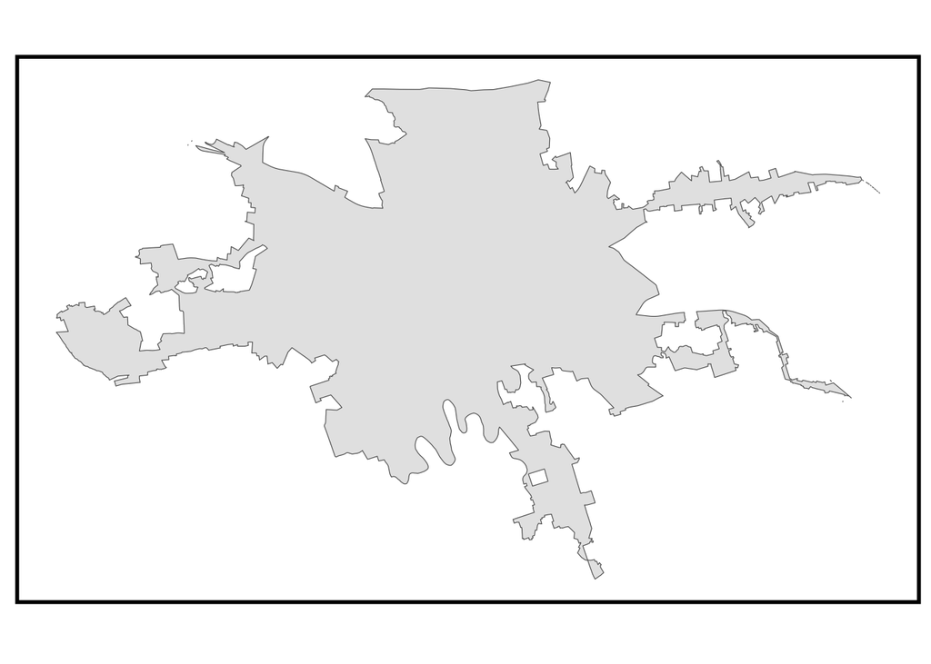

```r
ggplot() +
    geom_sf(data = uga_union) +
    mapTheme()
```

The point of this part of the chapter is determining places where extension of the urban growth boundary makes sense based on whether there is a large difference in density difference along the boundary. we are comparing the density 1/8th mile inside the boundary to that 1/8th mile outside the boundary.

```r
outsideBuffer <-
  st_buffer(uga_union, 660) %>%
  st_difference(uga_union) %>%
  mutate(Legend = "Outside")

insideBuffer <-
  st_buffer(uga_union, dist = -660) %>%
  st_difference(uga_union, .) %>%
  mutate(Legend = "Inside")

bothBuffers <- rbind(insideBuffer, outsideBuffer)
```

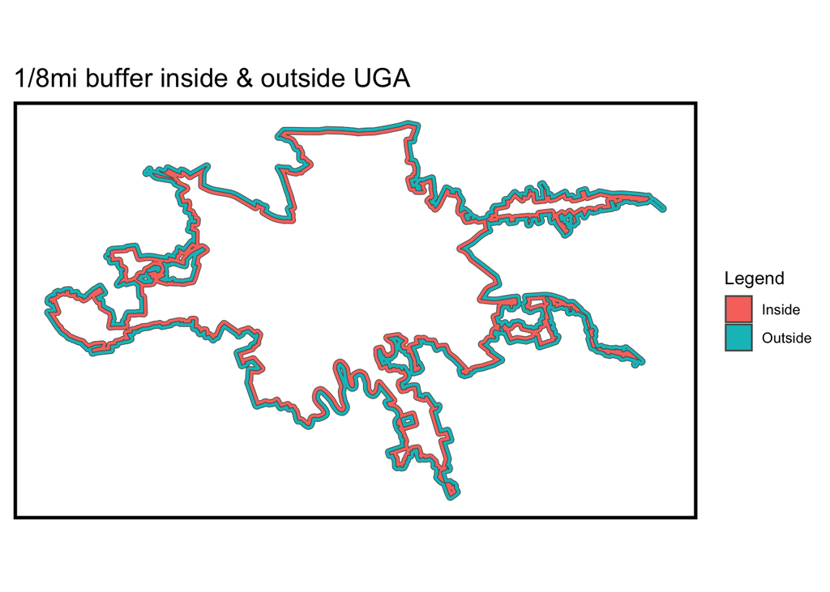

```r
ggplot() +
  geom_sf(data = bothBuffers, aes(fill = Legend)) +
  scale_fill_manual(values = c("#F8766D", "#00BFC4")) +
  labs(title = "1/8mi buffer inside & outside UGA") +
  mapTheme()
```

Sometimes when working with spatial data, one will come across ‘broken’ geometries. geometries are ‘broken’ when they break certain rules. for example, with a polygon, if it does not close or its lines intersect, it would be considered broken. The most common breaks can be easily fixed with functions as shown below.

```r
table(st_is_valid(studyAreaTowns))
```

```
##
## FALSE  TRUE
##     1    31
```

```r
buffersAndTowns <-
  st_intersection(st_make_valid(studyAreaTowns), bothBuffers) %>%
  filter(MUNI != "MOUNTVILLE BOROUGH" & MUNI != "MILLERSVILLE BOROUGH") # these towns appear on only one side of the UGA
arrange(buffersAndTowns, MUNI) %>% print(n=25)
```

```
## Simple feature collection with 25 features and 2 fields
## Geometry type: GEOMETRY
## Dimension:     XY
## Bounding box:  xmin: 2313271 ymin: -77880.5 xmax: 2425010 ymax: -10058.01
## Projected CRS: NAD_1983_StatePlane_Pennsylvania_North_FIPS_3701_Feet
##                         MUNI  Legend                       geometry
## 25         CITY OF LANCASTER  Inside POLYGON ((2380504 -48137.38...
## 25.1       CITY OF LANCASTER Outside MULTIPOLYGON (((2380728 -49...
## 31          COLUMBIA BOROUGH  Inside MULTIPOLYGON (((2317801 -40...
## 31.1        COLUMBIA BOROUGH Outside MULTIPOLYGON (((2319112 -40...
## 28   EAST HEMPFIELD TOWNSHIP  Inside MULTIPOLYGON (((2355430 -12...
## 28.1 EAST HEMPFIELD TOWNSHIP Outside POLYGON ((2354876 -11930.77...
## 30    EAST LAMPETER TOWNSHIP  Inside MULTIPOLYGON (((2387662 -26...
## 30.1  EAST LAMPETER TOWNSHIP Outside MULTIPOLYGON (((2389300 -25...
## 20   EAST PETERSBURG BOROUGH  Inside POLYGON ((2361240 -17965.16...
## 20.1 EAST PETERSBURG BOROUGH Outside MULTIPOLYGON (((2357112 -22...
## 1         LANCASTER TOWNSHIP  Inside POLYGON ((2381399 -48142.22...
## 23        LANCASTER TOWNSHIP  Inside MULTIPOLYGON (((2374606 -48...
## 23.1      LANCASTER TOWNSHIP Outside MULTIPOLYGON (((2373168 -50...
## 29          MANHEIM TOWNSHIP  Inside POLYGON ((2361240 -17965.16...
## 29.1        MANHEIM TOWNSHIP Outside MULTIPOLYGON (((2360956 -17...
## 27            MANOR TOWNSHIP  Inside MULTIPOLYGON (((2357129 -60...
## 27.1          MANOR TOWNSHIP Outside MULTIPOLYGON (((2362789 -60...
## 18           PEQUEA TOWNSHIP  Inside MULTIPOLYGON (((2368606 -57...
## 18.1         PEQUEA TOWNSHIP Outside MULTIPOLYGON (((2378325 -62...
## 19    UPPER LEACOCK TOWNSHIP  Inside MULTIPOLYGON (((2413106 -22...
## 19.1  UPPER LEACOCK TOWNSHIP Outside MULTIPOLYGON (((2409809 -21...
## 32   WEST HEMPFIELD TOWNSHIP  Inside MULTIPOLYGON (((2333916 -18...
## 32.1 WEST HEMPFIELD TOWNSHIP Outside MULTIPOLYGON (((2333537 -18...
## 26    WEST LAMPETER TOWNSHIP  Inside MULTIPOLYGON (((2391546 -49...
## 26.1  WEST LAMPETER TOWNSHIP Outside MULTIPOLYGON (((2395436 -52...
```

the textbook challenges us to visualize `buffersAndTowns` in a way that makes sense

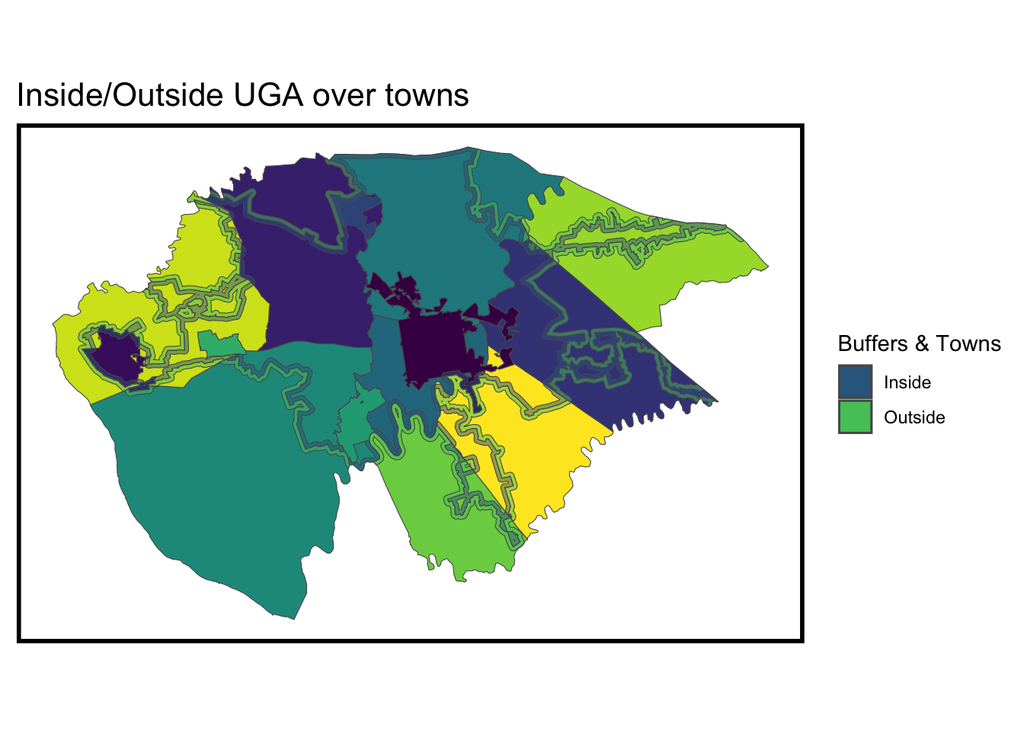

```r
ggplot() +
    geom_sf(data = studyAreaTowns, aes(fill = MUNI)) +
    geom_sf(data = buffersAndTowns, aes(fill = Legend), alpha = .5) +
    labs(title = "Inside/Outside UGA over towns") +
    scale_fill_viridis_d(name = "Buffers & Towns",
                       breaks = unique(buffersAndTowns$Legend),
                       labels = unique(buffersAndTowns$Legend)) +
    mapTheme()
```

```r
buildingCentroids <-
  st_centroid(buildings) %>% #creates a centroid for each build. essentially getting a point instead of a polygon
  mutate(counter = 1) %>% # a numeric value that will be used to sum up the number of buildings within an area.
  dplyr::select(counter) # we are left with the building centroid and the 1 representing its value as a single building

buffersAndTowns_Buildings <-
  aggregate(buildingCentroids, buffersAndTowns, sum) %>% #spatially joins the building centroids to the buffer and town it belongs to. sum sums up our counter row by by buffer and town. essentially giving us our buildings per buffer town.
  cbind(buffersAndTowns) %>%
  mutate(counter = replace_na(counter, 0),
         Area = as.numeric(st_area(.)))
```

```r
view(
buffersAndTowns_Buildings %>%
summarize(Building_Count = sum(counter))
    )
view(
buffersAndTowns_Buildings %>%
  group_by(MUNI) %>% #group_by when used in conjuction with summarzie or other "verb" functions works to ensure that we get the summary stats for variables by the specified group instead of the the tables as a whole
    summarize(Building_Count = sum(counter))
    )
```

```r
buffersAndTowns_Buildings_Summarize <-
  buffersAndTowns_Buildings %>%
  group_by(MUNI, Legend) %>%
    summarize(Building_Count = sum(counter),
              Area = sum(Area)) %>%
    mutate(Building_Density = Building_Count / Area)
buildingDifferenceTable <-
  st_drop_geometry(buffersAndTowns_Buildings_Summarize) %>%
    dplyr::select(MUNI, Legend, Building_Density) %>%
    spread(Legend, Building_Density) %>% # we want Inside and Outside to be in the same row for each town. the spread function takes the inside and outside values and makes them their own columns and fills in the building_density values as their values.
      mutate(Building_Difference = Inside - Outside) %>%
      arrange(desc(Building_Difference))
```

```r
westHempfield <-
  filter(studyAreaTowns, MUNI == "WEST HEMPFIELD TOWNSHIP")

uga_WH <-
  st_intersection(uga, westHempfield) %>% #selects the overlap of the polygons uga and westHempfiled
  st_union() %>%
  st_sf()
buildings_WH <-
  rbind(
    buildings[uga_WH,] %>%              #Within... it seems like using the brackets we are able to spatially join and find which buildings fall within uga_WH
      mutate(Legend = "Inside UGA"),
    buildings[westHempfield,] %>%       #Without
      .[uga_WH, , op = st_disjoint] %>%
      mutate(Legend = "Outside UGA"))
```

The book challenges us to recreate the map it shows.

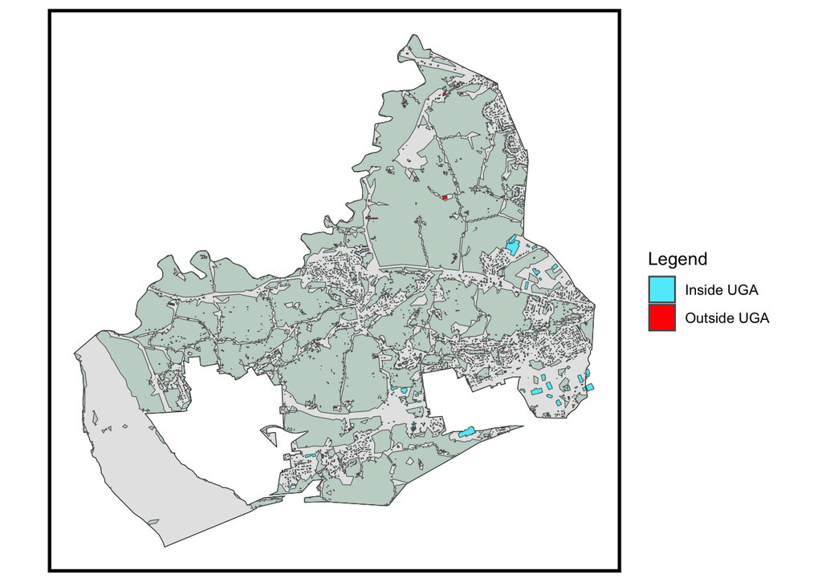

```r
WestHempfield_BuildingsPlot <-
ggplot() +
    geom_sf(data = westHempfield, color = "black") +
    geom_sf(data = st_intersection(greenSpace, westHempfield), fill = "#239162", alpha = .2) +
    geom_sf(data = buildings_WH, aes(fill = Legend)) +
    scale_fill_manual(values = c("#5becfc", "red")) +
    mapTheme()
studyAreaCutoutMap <-
ggplot() +
    geom_sf(data = studyAreaTowns, fill = "grey") +
    geom_sf(data = westHempfield, fill = "black") +
    mapTheme()

print(WestHempfield_BuildingsPlot)
```

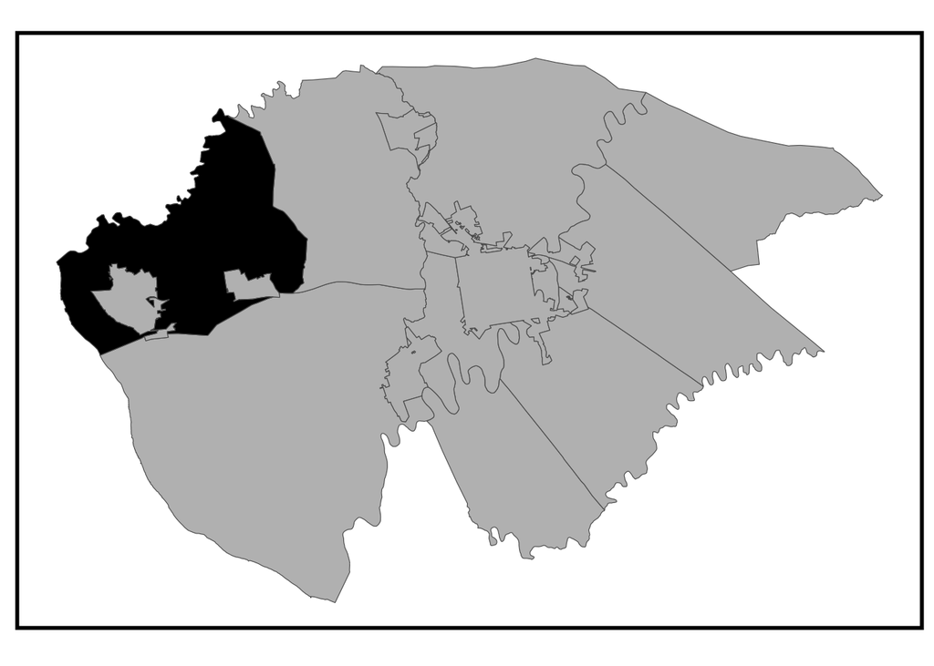

```r
print(studyAreaCutoutMap)
```

```r
multipleRing <-
  rbind(
    multipleRingBuffer(uga_union, -14520, -660) %>% #the first number indicates the greatest distanced ring and the second number represents the intervals for each ring
    mutate(Legend = "Inside the UGA"),
      multipleRingBuffer(uga_union, 26400, 660) %>%
      mutate(Legend = "Outside the UGA"))
```

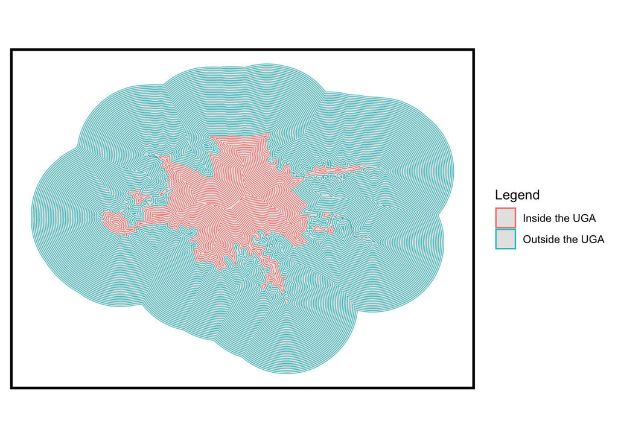

```r
ggplot() +
    geom_sf(data = uga_union, color = "black") +
    geom_sf(data = multipleRing, aes(color = Legend)) +
    mapTheme()
```

the textbook doesnt give a good explanation of how to use `scale_fill_gradient2` to make the map shown in the textbook. so we aren’t gonna worry about that too much.

```r
RingsAndTowns <-
  st_intersection(multipleRing, st_make_valid(studyAreaTowns)) # essentially divides the rings by each town boundary, essentially breaks up each town by distance from the city center.
buildings.in.RingsAndTowns <-
  aggregate(buildingCentroids,
            RingsAndTowns, sum) %>% # adds up all the buildings within each ring by town
  cbind(RingsAndTowns) %>% # we now how the number of buidlings per ring by town added to RingsAndTowns
  dplyr::select(-geometry.1) %>% # I guess we have multiple geometries, and this drops one of them. not sure what happens when have a sf with multiple geometries ?
  mutate(counter = replace_na(counter, 0),
         Area = as.numeric(st_area(.))) # we ultimately get a sf with the number of buildings per ring by town as well as the total area of each ring by town
```

The book creates some useful looking plots of density by distance and the bid rent curves. It doesnt give us the code but gives some hints on how to do it. let’s try.

```r
buildings.in.RingsAndTowns <- buildings.in.RingsAndTowns %>%
    mutate(Building_Density = counter/Area)

summ_density_distance <- buildings.in.RingsAndTowns %>%
         st_drop_geometry() %>%
         group_by(distance) %>%
         summarise(Building_Density = sum(Building_Density), Legend = Legend)
```

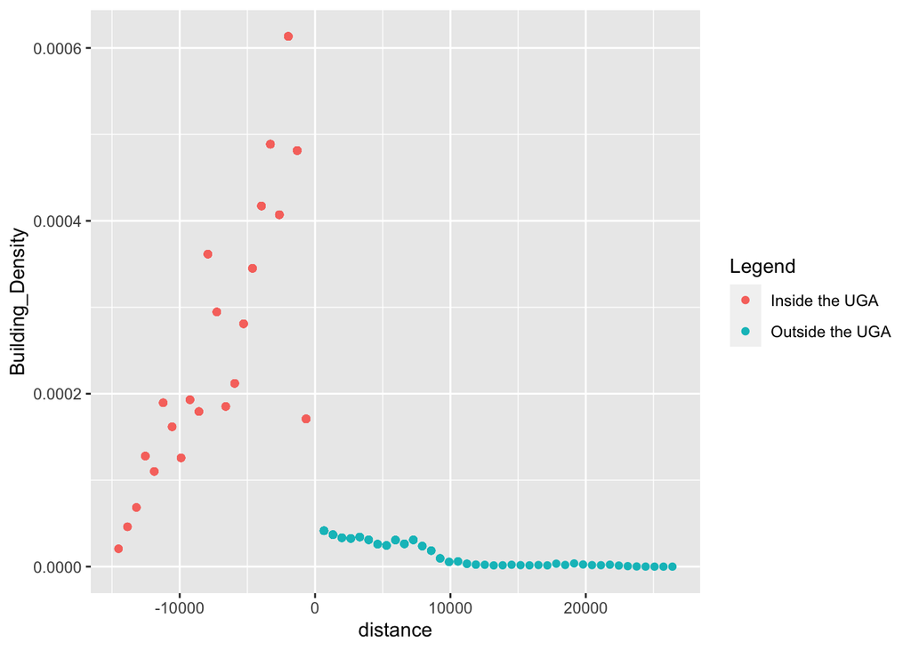

```r
ggplot(
   summ_density_distance,
       aes(x = distance, y = Building_Density, color = Legend)
        ) +
    geom_point()
```

```r
view(buildings.in.RingsAndTowns %>%
         group_by(distance) %>%
         summarise(densityByDistance = sum(Building_Density))
    )
```